Boats Segmentation: Cluster Analysis

**Heidi Wildemann, Miguel Ramos, Tilo Neumann, Tim Heal and Nanne Louw**

## Business Decisions

In response to a slow down in the boating market, CreeqBoat is looking into different growth opportunities, mainly in the North America region. In order to effectively assess their options and potential, CreeqBoat needs to better understand their customers and their purchasing preference and behaviors. They will need to analzye which different segments of customers are in the market, what each specific segment wants and needs in a boat and what CreeqBoat could or should offer them.

In order to arrive at such a business strategy, CreeqBoat has approached a market research firm to gather data in the US market on boating and boating preferences.

## The Data

The data used as a basis for the segmentation were the results of a survey on boating behavior, preference and attitudes. Here, 82 questions were asked and scored by almost 3,000 boat owners or people intending to buy a boat. The questions included 29 behavioral questions supplemented by questions about demographics and situational preference. The behavioral questions were scored on a 5-point scale, others on a binary metric scale (e.g. gender) making the results of the survey metric data. As 29 different attitudes and behaviors were too complex and varied to use to determine different clusters of respondents in the data, we grouped the data according to six different factors in the step prior to this exercise, whilst trying to maintain as much of the variance within the data as possible. Based on these factors, which tell us something about the different motivations for buying boats, we will now cluster our respondents into different groups of persona - differentiated by their socioeconomic status, demographic characteriscs and boating preferences and attitudes that will help us identify how to best tailor our marketing strategy to these consumers.

## Our Approach

1. Confirm the data in metric
2. Decide whether to scale or standardize the data
3. Decide which variables to use for clustering
4. Define similarity or dissimilarity measures between observations
5. Visualize Individual Attributes and Pair-wise Distances between the Observations
6. Select the clustering method to use and decide how many clusters to have
7. Profile and interpret the clusters
8. Assess the robustness of our clusters

Let's follow these steps.

#### 2. Decide whether to scale or standardize the data

```r
ProjectData_scaled = apply(ProjectData, 2, function(r) {
    if (sd(r) != 0)
        res = (r - mean(r))/sd(r) else res = 0 * r
    res
})
```

While this is typically a necessary step, one has to always do it with care: some times you may want your analytics findings to be driven mainly by a few attributes that take large values; other times having attributes with different scales may imply something about those attributes. In many such cases one may choose to skip step 2 for some of the raw attributes.

We decide to use the unscaled data for now.

#### Step 3. Decide which variables to use for clustering

The factor analysis revealed a number of distinct motivations for the survey respondents, which we could use to see whether specific segments within the respondents exist. Based on the analysis specific questions or clusters of questions revealed specific attitudes or behaviors within the population. Specifically, questions 1.21, 1.27, 1.09, 1.04, 1.02 and 1.11 were shown to significantly stand out in determining the variance between reponses in the survey data.

These questions were indicated as input for the cluster analysis, where the program searches for clusters of respondents that answer similarly to the indicated questions. In other words, the program looks which clusters of respondents have the same behavior or attitude, based on the six distinct behavioral attitudes we identified in the previous analysis.

As the analysis of “big” or diverse data is an iterative process, we changed the amount of clusters varying from 4 to 8, ultimately settling on 5 clusters based on our interpretation and the stability of the clusters with varying methods of analysis.

#### Step 4. Define similarity or dissimilarity measures between observations

In our case we explore two distance metrics: the commonly used **Euclidean distance** as well as a simple one we define manually.

Pairwise Distances between the first 5 observations using The Euclidean Distance Metric

| 1 | 2 | 3 | 4 | 5 |
| --- | --- | --- | --- | --- |
| 0.0 |  |  |  |  |
| 2.4 | 0.0 |  |  |  |
| 2.4 | 2.0 | 0.0 |  |  |
| 3.2 | 2.0 | 3.2 | 0.0 |  |
| 3.5 | 2.4 | 3.7 | 2.8 | 0.0 |

Notice for example that if we use, say, the Manhattan distance metric, these distances change as follows:

Pairwise Distances between the first 5 observations using The Manhattan Distance Metric

| 1 | 2 | 3 | 4 | 5 |
| --- | --- | --- | --- | --- |
| 0.0 |  |  |  |  |
| 6.0 | 0.0 |  |  |  |
| 4.0 | 4.0 | 0.0 |  |  |
| 6.0 | 4.0 | 6.0 | 0.0 |  |
| 6.0 | 4.0 | 8.0 | 6.0 | 0.0 |

Let's now define our own distance metric, as an example. Let's say that the management team of the company believes that two customers are similar if they do not differ in their ratings of the attitudinal questions by more than 2 points. We can manually assign a distance of 1 for every question for which two customers gave an answer that differs by more than 2 points, and 0 otherwise. It is easy to write this distance function in R:

```r
My_Distance_function <- function(x, y) {
    sum(abs(x - y) > 2)
}
```

Here is how the pairwise distances between the respondents now look like.

Pairwise Distances between the first 5 observations using a simple manually defined Distance Metric

| 1 | 2 | 3 | 4 | 5 |
| --- | --- | --- | --- | --- |
| 0.0 |  |  |  |  |
| 0.0 | 0.0 |  |  |  |
| 0.0 | 0.0 | 0.0 |  |  |
| 0.0 | 0.0 | 0.0 | 0.0 |  |
| 1.0 | 0.0 | 1.0 | 0.0 | 0.0 |

In general a lot of creative thinking and exploration should be spent in this step, and as always one may need to come back to this step even after finishing the complete segmentation process - multiple times.

#### Step 5. Visualize Individual Attributes and Pair-wise Distances between the Observations

or the histogram of all pairwise distances for the euclidean distance:

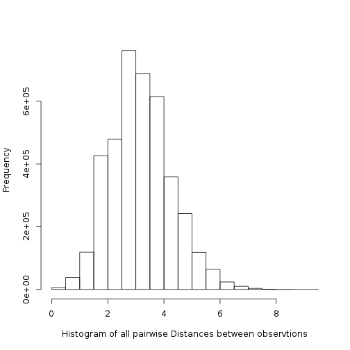

> Visualization is very important for data analytics, as it can provide a first understanding of the data.

#### Step 6. Select the clustering method to use and decide how many clusters to have

As the analysis of such data sets is an iterative process, we experimented with different cluster numbers (four to eight to be exact) in combination with the six factors we determined to represent distinct motivational drivers. In our opinion, the most clearly separable and defined target consumer profiles were derived when running five clusters with six factors.

In this note we will use two widely used methods: the **Kmeans Clustering Method**, and the **Hierarchical Clustering Method**. Like all clustering methods, these two also require that we have decided how to measure the distance/similarity between our observations. Explaining how these methods work is beyond our scope. The only difference to highlight is that Kmeans requires the user to define how many segments to create, while Hierarchical Clustering does not.

Let's fist use the **Hierarchial Clustering** method, as we do not know for now how many segments there are in our data. Hierarchical clustering is a method that also helps us visualise how the data may be clustering together. It generates a plot called the **Dendrogram** which is often helpful for visualization - but should be used with care. For example, in this case the dendrogram, using the euclidean distance metric from the earlier steps and the ward hierarchical clustering option (see below as well as help(hclust) in R for more information), is as follows:

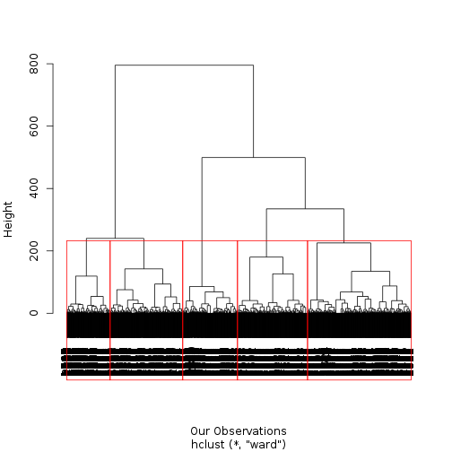

Note that we can draw as many clusters are we choose (e.g. in this case we chose 5 clusters) around the branches of the Dendrogram.

#### Step 7. Profile and interpret the clusters

Cluster 1 : [Socialite Sailor (Wo)Man] Our first cluster is dominated by women. This cluster is interested in boating as a social activity but isn't particularly knowledgeable about boats. While they do view boats as a status symbol and it is the number 1 activity in their spare time, the fact that their knowledge on boats is low indicates that this group are not fanatic boaters. Possible consumers could be socialite wives of fanatic boaters who recognize the importance of sailing as a social event or their young, professional daughters. Potentially, this also includes young professionals who grew up in a boating household and now practice it as member of a club on occasion.

Cluster 2: [The Bulls of Sail Street] This cluster is male dominated. Its most pertinent characteristic are the importance of power and status that comes with boating. This group shows little price sensitivity and wants its boats to come with all the frills possible. While boating is a sport to this group and they are very knowledgeable about the sport itself as well as the equipment, boating is first and foremost a manifestation of their success.

Cluster 3: [Future Yacht Leaders of America]: This cluster is characterized by a predominantly younger age demographic. Like their (potentially Cluster 2) fathers, this generation values boating as both a sport as well as a symbol of success, achievement ad power. However, at this stage of their life they are price sensitive - hence leading to them not being able to own their equipment. However, they are differentiated from the no frills buyer in the sense that they can appreciate the quality of a brand name boat and would consider spending money on it, could they afford it.

Cluster 4: [Fresh off the Boat] This cluster of customers is characterized by utter and complete novices. This profile group doesn't own any of their own boating equipment nor are they particularly knowledgeable about boating (yet). However, it should be noted that this could potentially stem from newness alone and as this group is characterized by high employment rate, it is a cluster worth monitoring/targeting.

We can also “visualize” the segments using **snake plots** for each cluster. For example, we can plot the means of the profiling variables for each of our clusters to better visualize differences between segments. For better visualization we plot the standardized profiling variables.

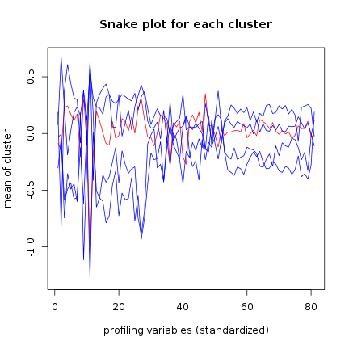

See above…

We can also compare the averages of the profiling variables of each segment relative to the average of the variables across the whole population. This can also help us better understand whether there are indeed clusters in our data (e.g. if all segments are much like the overall population, there may be no segments). For example, we can measure the ratios of the average for each cluster to the average of the population (e.g. avg(clu)/avg(population)) and explore a matrix as the following one:

|  | Segment 1 | Segment 2 | Segment 3 | Segment 4 | Segment 5 |
| --- | --- | --- | --- | --- | --- |
| Q1_1_When buying a boat I do a lot of shopping around and visit multiple dealers | 0.9826 | 1.039 | 1.016 | 0.9378 | 0.9936 |
| Q1_2_When buying a boat getting the lowest price is more important than the boat brand | 0.9483 | 0.7123 | 1.238 | 0.9857 | 0.9976 |
| Q1_3_The brand of boat I buy says a lot about who I am | 1.074 | 1.123 | 1.074 | 0.8074 | 0.7554 |
| Q1_4_I only consider buying a boat from a reputable brand | 1.052 | 1.128 | 0.9598 | 0.8964 | 0.9258 |
| Q1_5_I am willing to pay a premium for a brand with a reputation for high quality | 1.044 | 1.116 | 1.006 | 0.8865 | 0.8716 |
| Q1_6_Owning a boat is a way of rewarding myself for my hard work | 1.023 | 1.066 | 1.038 | 0.8797 | 0.908 |
| Q1_7_Owning a boat gives me a sense of achievement | 1.042 | 1.072 | 1.057 | 0.8617 | 0.853 |
| Q1_8_When buying a boat functionality is more important than style | 0.9552 | 0.9814 | 1.034 | 0.9731 | 1.04 |
| Q1_9_I see my boat as a status symbol | 1.112 | 1.143 | 1.141 | 0.7691 | 0.5837 |
| Q1_10_When buying a boat I rely more on expert opinion than my own e g consumer reports salespeople | 1.034 | 0.972 | 1.032 | 1.009 | 0.9229 |
| Q1_11_I tend to perform minor boat repairs and maintenance on my own | 0.6397 | 1.211 | 1.181 | 0.568 | 1.209 |
| Q1_12_When it comes to boating I tend to prefer a basic boat with little to no frills | 0.933 | 0.8528 | 1.112 | 1.004 | 1.062 |
| Q1_13_When buying a boat I tend to buy the latest and greatest | 1.063 | 1.088 | 1.076 | 0.8358 | 0.7889 |
| Q1_14_When buying accessories for my boat I tend to buy the latest and greatest | 1.033 | 1.104 | 1.067 | 0.8297 | 0.8306 |
| Q1_15_I am serious about the technology on my boat | 1.001 | 1.098 | 1.042 | 0.8531 | 0.9105 |
| Q1_16_People tend to come to me for advice about boating | 0.9701 | 1.147 | 1.11 | 0.7339 | 0.8548 |
| Q1_17_I consider myself more knowledgeable about boating than the rest of my boating peers | 0.9675 | 1.109 | 1.109 | 0.7707 | 0.8796 |
| Q1_18_Boating gives me a feeling of adventure | 1.019 | 1.051 | 1.011 | 0.9178 | 0.9541 |
| Q1_19_Boating allows me to experience nature | 0.9929 | 1.046 | 1.009 | 0.943 | 0.979 |
| Q1_20_When not on my boat I often find myself doing boating related activities | 0.9945 | 1.092 | 1.106 | 0.777 | 0.8658 |
| Q1_21_Boating helps me escape from everyday life and relax | 1.023 | 1.059 | 0.9958 | 0.9101 | 0.9739 |
| Q1_22_Boating helps me stay active | 1.019 | 1.06 | 1.018 | 0.8923 | 0.9497 |
| Q1_23_Boating allows me to excel in the sports that I am passionate about e g fishing racing water sports | 1.007 | 1.087 | 1.059 | 0.8356 | 0.899 |
| Q1_24_Boating gives me an outlet to socialize with family and or friends | 1.027 | 1.053 | 1.006 | 0.9283 | 0.9425 |
| Q1_25_Being in charge of my boat is very important to me | 1.00 | 1.086 | 1.057 | 0.8136 | 0.9294 |
| Q1_26_Having a powerful boat is what is most important to me | 1.076 | 1.073 | 1.118 | 0.8068 | 0.7349 |
| Q1_27_Boating is the number one thing I do with my spare time | 1.103 | 1.107 | 1.142 | 0.689 | 0.7039 |
| Q1_28_Boating is my true passion in life | 1.037 | 1.11 | 1.101 | 0.7772 | 0.7971 |
| Q1_29_Boating is one of many things I do in my spare time | 0.9942 | 1.04 | 1.02 | 0.9191 | 0.9831 |
| Q2_How many powerboats do you currently own | 0.9712 | 1.069 | 1.043 | 0.8502 | 0.988 |

[output cut: 51 more lines]

#### Step 8. Assess the robustness of our clusters

We will skip this step for this exercise. However in practice this is a very important step.